# Week One In-class Exercise

# Anscombe Data Set

The Anscombe data set is indroduced in the *NIST Engineering and Statistics Handbook* to demonstrate the value of Exporatory Data Analysis (EDA)

```r
library(readxl)
Anscombe <- read_excel("~/Google Drive/UU PMST/MST 6600 - Advanced Statistical Techniques/NIST Engineering Statistics Handbook 1-1-6 EDA Graphics Example/data/Anscombe.xlsx")
```

Although this looks like a lot of code, it was generated using the **Import Dataset** dropdown box.

We can view the data in the concole, “viewer,” or in the table below:

```r
Anscombe
```

| X1 | Y1 | X2 | Y2 | X3 | Y3 | X4 | Y4 |
| --- | --- | --- | --- | --- | --- | --- | --- |
| 10 | 8.04 | 10 | 9.14 | 10 | 7.46 | 8 | 6.58 |
| 8 | 6.95 | 8 | 8.14 | 8 | 6.77 | 8 | 5.76 |
| 13 | 7.58 | 13 | 8.74 | 13 | 12.74 | 8 | 7.71 |
| 9 | 8.81 | 9 | 8.77 | 9 | 7.11 | 8 | 8.84 |
| 11 | 8.33 | 11 | 9.26 | 11 | 7.81 | 8 | 8.47 |
| 14 | 9.96 | 14 | 8.10 | 14 | 8.84 | 8 | 7.04 |
| 6 | 7.24 | 6 | 6.13 | 6 | 6.08 | 8 | 5.25 |
| 4 | 4.26 | 4 | 3.10 | 4 | 5.39 | 19 | 12.50 |
| 12 | 10.84 | 12 | 9.13 | 12 | 8.15 | 8 | 5.56 |
| 7 | 4.82 | 7 | 7.26 | 7 | 6.42 | 8 | 7.91 |

[output cut: 1 more lines]

## What’s intersting about this data set?

Given we have a set of X and Y pairs, we may assume that data should be grouped together; a normal, *non-graphical* analysis would be to preform a linear regression on the data.

```r
xy1.linear.model <- lm(Anscombe$Y1 ~ Anscombe$X1)
summary(xy1.linear.model)
```

```
Call:
lm(formula = Anscombe$Y1 ~ Anscombe$X1)

Residuals:
     Min       1Q   Median       3Q      Max
-1.92127 -0.45577 -0.04136  0.70941  1.83882

Coefficients:
            Estimate Std. Error t value Pr(>|t|)
(Intercept)   3.0001     1.1247   2.667  0.02573 *
Anscombe$X1   0.5001     0.1179   4.241  0.00217 **
---
Signif. codes:  0 ‘***’ 0.001 ‘**’ 0.01 ‘*’ 0.05 ‘.’ 0.1 ‘ ’ 1

Residual standard error: 1.237 on 9 degrees of freedom
Multiple R-squared:  0.6665,    Adjusted R-squared:  0.6295
F-statistic: 17.99 on 1 and 9 DF,  p-value: 0.00217
```

I might even plot the data (adding the linear regression line from above):

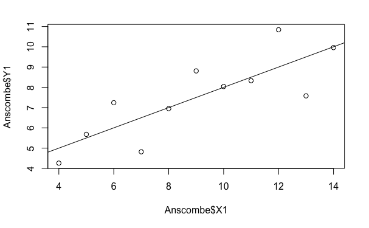

```r
plot(Anscombe$X1, Anscombe$Y1)
abline(xy1.linear.model)
```

### Create summaries of the other XY pairs

```r
xy2.linear.model <- lm(Anscombe$Y2 ~ Anscombe$X2)
xy3.linear.model <- lm(Anscombe$Y3 ~ Anscombe$X3)
xy4.linear.model <- lm(Anscombe$Y4 ~ Anscombe$X4)
```

```r
summary(xy2.linear.model)
```

```
Call:
lm(formula = Anscombe$Y2 ~ Anscombe$X2)

Residuals:
    Min      1Q  Median      3Q     Max
-1.9009 -0.7609  0.1291  0.9491  1.2691

Coefficients:
            Estimate Std. Error t value Pr(>|t|)
(Intercept)    3.001      1.125   2.667  0.02576 *
Anscombe$X2    0.500      0.118   4.239  0.00218 **
---
Signif. codes:  0 ‘***’ 0.001 ‘**’ 0.01 ‘*’ 0.05 ‘.’ 0.1 ‘ ’ 1

Residual standard error: 1.237 on 9 degrees of freedom
Multiple R-squared:  0.6662,    Adjusted R-squared:  0.6292
F-statistic: 17.97 on 1 and 9 DF,  p-value: 0.002179
```

```r
summary(xy3.linear.model)
```

```
Call:
lm(formula = Anscombe$Y3 ~ Anscombe$X3)

Residuals:
    Min      1Q  Median      3Q     Max
-1.1586 -0.6146 -0.2303  0.1540  3.2411

Coefficients:
            Estimate Std. Error t value Pr(>|t|)
(Intercept)   3.0025     1.1245   2.670  0.02562 *
Anscombe$X3   0.4997     0.1179   4.239  0.00218 **
---
Signif. codes:  0 ‘***’ 0.001 ‘**’ 0.01 ‘*’ 0.05 ‘.’ 0.1 ‘ ’ 1

Residual standard error: 1.236 on 9 degrees of freedom
Multiple R-squared:  0.6663,    Adjusted R-squared:  0.6292
F-statistic: 17.97 on 1 and 9 DF,  p-value: 0.002176
```

```r
summary(xy4.linear.model)
```

```
Call:
lm(formula = Anscombe$Y4 ~ Anscombe$X4)

Residuals:
   Min     1Q Median     3Q    Max
-1.751 -0.831  0.000  0.809  1.839

Coefficients:
            Estimate Std. Error t value Pr(>|t|)
(Intercept)   3.0017     1.1239   2.671  0.02559 *
Anscombe$X4   0.4999     0.1178   4.243  0.00216 **
---
Signif. codes:  0 ‘***’ 0.001 ‘**’ 0.01 ‘*’ 0.05 ‘.’ 0.1 ‘ ’ 1

Residual standard error: 1.236 on 9 degrees of freedom
Multiple R-squared:  0.6667,    Adjusted R-squared:  0.6297
F-statistic:    18 on 1 and 9 DF,  p-value: 0.002165
```

### Let’s look at all the data graphically

```r
# create a single page of all values
par(mfrow=c(2,2)) # Change the panel layout to 2 x 2
plot(Anscombe$X1, Anscombe$Y1)
abline(xy1.linear.model)
```

```r
plot(Anscombe$X2, Anscombe$Y2)
abline(xy2.linear.model)
```

```r
plot(Anscombe$X3, Anscombe$Y3)
abline(xy3.linear.model)
```

```r
plot(Anscombe$X4, Anscombe$Y4)
abline(xy4.linear.model)
```

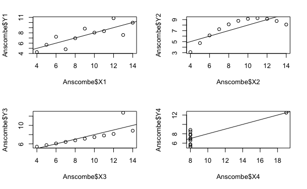

```r
par(mfrow=c(1,1)) # Change back to 1 x 1
```

### Let’s make one of the graphs “pretty”

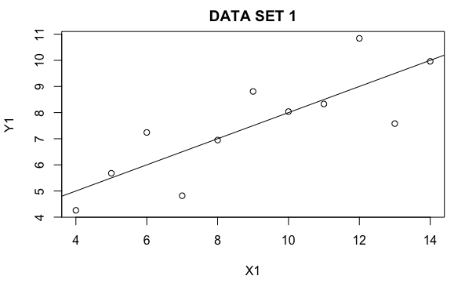

```r
# Making changes to graphs
# create a simple scatter plot of X1 vs Y1 with some lables
plot(Anscombe$X1, Anscombe$Y1, main="DATA SET 1", xlab="X1", ylab="Y1")
abline(xy1.linear.model)
```

### What else do I get with R?

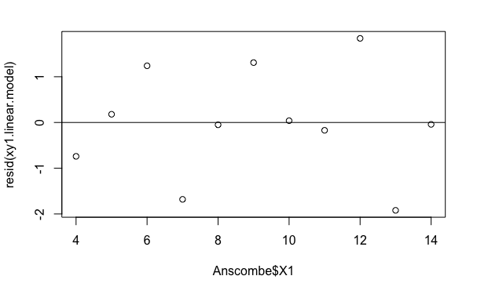

```r
plot(Anscombe$X1, resid(xy1.linear.model))
abline(h = 0)
```

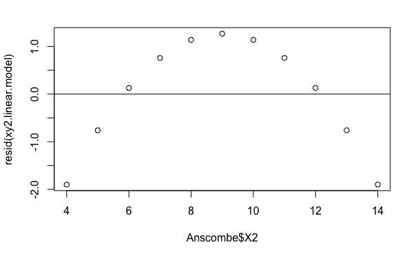

```r
plot(Anscombe$X2, resid(xy2.linear.model))
abline(h = 0)
```

# A Look Ahead

The code above uses *base R* commands. While they can be used to create clean, accurate graphs, it requires the user to **know** many different commands and structures.

Over the last 10-years, several new R packages have been created to make analysis and graphics easier. This course will primarily exploit two of those packages: *tidyverse* and *ggplot2*.

## Example 2. The Anscombe dataset with ggplot2

I need to tidy up the data:

```r
library(tidyverse)
```

```r
Anscombe.tidy.xy1 <- Anscombe %>% select("X1", "Y1") %>%
  mutate(dataset = "DataSet1") %>%
  rename(X = X1, Y = Y1) %>% as_tibble()
Anscombe.tidy.xy2 <- Anscombe %>% select("X2", "Y2") %>%
  mutate(dataset = "DataSet2") %>%
  rename(X = X2, Y = Y2)
Anscombe.tidy.xy3 <- Anscombe %>% select("X3", "Y3") %>%
  mutate(dataset = "DataSet3") %>%
  rename(X = X3, Y = Y3)
Anscombe.tidy.xy4 <- Anscombe %>% select("X4", "Y4") %>%
  mutate(dataset = "DataSet4") %>%
  rename(X = X4, Y = Y4)
```

We can look at the output of the first data set:

```r
Anscombe.tidy.xy1
```

| X | Y | dataset |
| --- | --- | --- |
| 10 | 8.04 | DataSet1 |
| 8 | 6.95 | DataSet1 |
| 13 | 7.58 | DataSet1 |
| 9 | 8.81 | DataSet1 |
| 11 | 8.33 | DataSet1 |
| 14 | 9.96 | DataSet1 |
| 6 | 7.24 | DataSet1 |
| 4 | 4.26 | DataSet1 |
| 12 | 10.84 | DataSet1 |
| 7 | 4.82 | DataSet1 |

[output cut: 1 more lines]

In order to fully complete the analysis, we need to put all for *datasets* together:

```r
Anscombe.tidy.data <-
  bind_rows(Anscombe.tidy.xy1, Anscombe.tidy.xy2, Anscombe.tidy.xy3, Anscombe.tidy.xy4)
```

The new dataset is “tidy.”

```r
Anscombe.tidy.data
```

| X | Y | dataset |
| --- | --- | --- |
| 10 | 8.04 | DataSet1 |
| 8 | 6.95 | DataSet1 |
| 13 | 7.58 | DataSet1 |
| 9 | 8.81 | DataSet1 |
| 11 | 8.33 | DataSet1 |
| 14 | 9.96 | DataSet1 |
| 6 | 7.24 | DataSet1 |
| 4 | 4.26 | DataSet1 |
| 12 | 10.84 | DataSet1 |
| 7 | 4.82 | DataSet1 |

[output cut: 34 more lines]

## The POWER of ggplot2

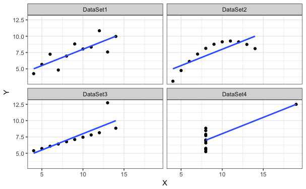

```r
Anscombe.tidy.data %>%
  ggplot(aes(X, Y)) +
  geom_point() +
  geom_smooth(method = "lm", se = FALSE) +
  facet_wrap(~ dataset) +
  theme_bw()
```

## Modeling is easier as well…

```r
# modeling the data for DataSet1 through DataSet4
xy1.lm <- Anscombe.tidy.data %>%
  filter(dataset == "DataSet1") %>% lm(Y ~ X, .)
#plot(xy1.lm)
summary(xy1.lm)
```

```
Call:
lm(formula = Y ~ X, data = .)

Residuals:
     Min       1Q   Median       3Q      Max
-1.92127 -0.45577 -0.04136  0.70941  1.83882

Coefficients:
            Estimate Std. Error t value Pr(>|t|)
(Intercept)   3.0001     1.1247   2.667  0.02573 *
X             0.5001     0.1179   4.241  0.00217 **
---
Signif. codes:  0 ‘***’ 0.001 ‘**’ 0.01 ‘*’ 0.05 ‘.’ 0.1 ‘ ’ 1

Residual standard error: 1.237 on 9 degrees of freedom
Multiple R-squared:  0.6665,    Adjusted R-squared:  0.6295
F-statistic: 17.99 on 1 and 9 DF,  p-value: 0.00217
```

```r
xy2.lm <- Anscombe.tidy.data %>%
  filter(dataset == "DataSet2") %>% lm(Y ~ X, .)
#plot(xy2.lm)
summary(xy2.lm)
```

```
Call:
lm(formula = Y ~ X, data = .)

Residuals:
    Min      1Q  Median      3Q     Max
-1.9009 -0.7609  0.1291  0.9491  1.2691

Coefficients:
            Estimate Std. Error t value Pr(>|t|)
(Intercept)    3.001      1.125   2.667  0.02576 *
X              0.500      0.118   4.239  0.00218 **
---
Signif. codes:  0 ‘***’ 0.001 ‘**’ 0.01 ‘*’ 0.05 ‘.’ 0.1 ‘ ’ 1

Residual standard error: 1.237 on 9 degrees of freedom
Multiple R-squared:  0.6662,    Adjusted R-squared:  0.6292
F-statistic: 17.97 on 1 and 9 DF,  p-value: 0.002179
```

```r
xy3.lm <- Anscombe.tidy.data %>%
  filter(dataset == "DataSet3") %>% lm(Y ~ X, .)
#plot(xy3.lm)
summary(xy3.lm)
```

```
Call:
lm(formula = Y ~ X, data = .)

Residuals:
    Min      1Q  Median      3Q     Max
-1.1586 -0.6146 -0.2303  0.1540  3.2411

Coefficients:
            Estimate Std. Error t value Pr(>|t|)
(Intercept)   3.0025     1.1245   2.670  0.02562 *
X             0.4997     0.1179   4.239  0.00218 **
---
Signif. codes:  0 ‘***’ 0.001 ‘**’ 0.01 ‘*’ 0.05 ‘.’ 0.1 ‘ ’ 1

Residual standard error: 1.236 on 9 degrees of freedom
Multiple R-squared:  0.6663,    Adjusted R-squared:  0.6292
F-statistic: 17.97 on 1 and 9 DF,  p-value: 0.002176
```

```r
xy4.lm <- Anscombe.tidy.data %>%
  filter(dataset == "DataSet4") %>% lm(Y ~ X, .)
#plot(xy4.lm)
summary(xy4.lm)
```

```
Call:
lm(formula = Y ~ X, data = .)

Residuals:
   Min     1Q Median     3Q    Max
-1.751 -0.831  0.000  0.809  1.839

Coefficients:
            Estimate Std. Error t value Pr(>|t|)
(Intercept)   3.0017     1.1239   2.671  0.02559 *
X             0.4999     0.1178   4.243  0.00216 **
---
Signif. codes:  0 ‘***’ 0.001 ‘**’ 0.01 ‘*’ 0.05 ‘.’ 0.1 ‘ ’ 1

Residual standard error: 1.236 on 9 degrees of freedom
Multiple R-squared:  0.6667,    Adjusted R-squared:  0.6297
F-statistic:    18 on 1 and 9 DF,  p-value: 0.002165
```